# Survival Analysis

Roman Susdorf

August 14, 2018

Survival analysis involves modelling of time to event data, with “event” in medical research commonly being death or occurance of disease.

In this example I will be assessing the difference in time of a specific event (e.g. death) between two or more groups of individuals.

I will analyse the *ovarian* dataset from the *survival* R-package. It’s documentation is available [here](https://stat.ethz.ch/R-manual/R-devel/library/survival/html/ovarian.html). This dataset contains clinical information on a cohort of ovarian cancer patients receiving two treatments. The patients were monitored until they either died or were censored (time variable *futime*).

First some R-packages have to be loaded and maybe also installed:

```r
if (!require("survival")) {
  install.packages("survival")
  library(survival)}
if (!require("survminer")) {
  install.packages("survminer")
  library(survminer)}
if (!require("dplyr")) {
  install.packages("dplyr")
  library(dplyr)}
```

Now examine the *ovarian* dataset

```r
ovarian<-ovarian
dim(ovarian)
```

```
## [1] 26  6
```

```r
summary(ovarian)
```

```
##      futime           fustat            age           resid.ds
##  Min.   :  59.0   Min.   :0.0000   Min.   :38.89   Min.   :1.000
##  1st Qu.: 368.0   1st Qu.:0.0000   1st Qu.:50.17   1st Qu.:1.000
##  Median : 476.0   Median :0.0000   Median :56.85   Median :2.000
##  Mean   : 599.5   Mean   :0.4615   Mean   :56.17   Mean   :1.577
##  3rd Qu.: 794.8   3rd Qu.:1.0000   3rd Qu.:62.38   3rd Qu.:2.000
##  Max.   :1227.0   Max.   :1.0000   Max.   :74.50   Max.   :2.000
##        rx         ecog.ps
##  Min.   :1.0   Min.   :1.000
##  1st Qu.:1.0   1st Qu.:1.000
##  Median :1.5   Median :1.000
##  Mean   :1.5   Mean   :1.462
##  3rd Qu.:2.0   3rd Qu.:2.000
##  Max.   :2.0   Max.   :2.000
```

There are 26 observations of 6 numeric variables:

*futime* is the response variable and represents the time (in days) until a patient died or was censored. Generally, censoring (in this case right-censoring) is present when a subject did not experience the event (here: death) until end of the study, or was lost to follow-up during the study period, or simply withdraw from the study.

*age* is the patient age in years

*resid.ds* tells about potential residual disease (tumors) being present (2) or not (1)

*rx* represents the two treatment groups

*ecog.ps* is a measure of patient performance status (ECOG) with 1 being better than 2

Survival curves will be plot using the *survfit* function. This function requires either a formula (e.g. **the Kaplan-Meier method**) or a previously fitted model (e.g. **Cox proportional hazards model**).

## Kaplan-Meier estimator

For the **Kaplan-Meier estimation method** only categorical covariates can be considered. Thus, we have to transform variables of interest from continuous to categorical data type. Let’s consider *age* as a predictor and see it’s distribution.

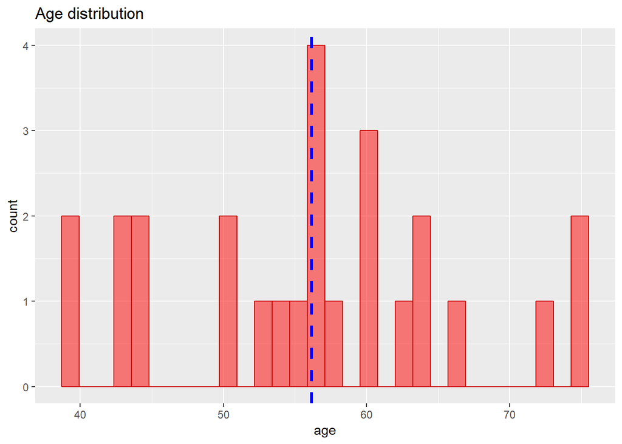

```r
library(ggplot2)
ggplot(ovarian, aes(x=age)) +
  geom_histogram(color="red3", fill="red", position="dodge", alpha=0.5)+
  geom_vline(data=data.frame(mean=mean(ovarian$age)), aes(xintercept=mean),color="blue", size=1.2,
             linetype="dashed")+theme(legend.position="none")+
  labs(title="Age distribution")
```

The variable *age* ranges from 38.89 to 74.50 with a mean of 56.17. We split the sample into 2 age categories with the border indicated by the dashed vertical line at the mean age value.  
Thus continuous variable *age* will be transformed into a categorical variable *age_cat* containing two age-categories:

```r
ovarian$age_cat <- as.factor(cut(ovarian$age, c(0,56,Inf), labels = c("young","old"), include.lowest = TRUE))
# check for correctness
table(ovarian$age_cat, ovarian$age)
```

```
##
##         38.8932 39.2712 43.1233 43.137 44.2055 44.6 50.1096 50.3397
##   young       1       1       1      1       1    1       1       1
##   old         0       0       0      0       0    0       0       0
##
##         53.3644 53.9068 55.1781 56.4301 56.7562 56.937 57.0521 58.3096
##   young       1       1       1       0       0      0       0       0
##   old         0       0       0       1       1      1       1       1
##
##         59.589 59.6301 59.8548 63.2192 64.1753 64.4247 66.4658 72.3315
##   young      0       0       0       0       0       0       0       0
##   old        1       1       1       1       1       1       1       1
##
##         74.4932 74.5041
##   young       0       0
##   old         1       1
```

I will also categorise each of the other potential predictors and change their labels:

```r
ovarian$resid.ds<-factor(ovarian$resid.ds, levels=c('1','2'), labels=c('neg','pos'))
ovarian$treatment<-factor(ovarian$rx, levels=c('1','2'), labels=c('X','Y'))
ovarian$ecog.ps<-factor(ovarian$ecog.ps, levels=c('1','2'), labels=c('good','bad'))
```

Starting with the **Kaplan-Meier method**, a formula is used as a survival object *surv.obj*:

```r
surv.obj<-Surv(time=ovarian$futime, event=ovarian$fustat)
surv.obj
```

```
##  [1]   59   115   156   421+  431   448+  464   475   477+  563   638
## [12]  744+  769+  770+  803+  855+ 1040+ 1106+ 1129+ 1206+ 1227+  268
## [23]  329   353   365   377+
```

Censored data points in *surv.obj* are indicated by a **+** sign.

The *surv.obj* formula can now be implemented in the function *survfit* to create survival curves given stratification of patients into e.g. treatment groups (factor *treatment*):

```r
km1<-survfit(surv.obj ~ treatment, ovarian)
summary(km1)
```

```
## Call: survfit(formula = surv.obj ~ treatment, data = ovarian)
##
##                 treatment=X
##  time n.risk n.event survival std.err lower 95% CI upper 95% CI
##    59     13       1    0.923  0.0739        0.789        1.000
##   115     12       1    0.846  0.1001        0.671        1.000
##   156     11       1    0.769  0.1169        0.571        1.000
##   268     10       1    0.692  0.1280        0.482        0.995
##   329      9       1    0.615  0.1349        0.400        0.946
##   431      8       1    0.538  0.1383        0.326        0.891
##   638      5       1    0.431  0.1467        0.221        0.840
##
##                 treatment=Y
##  time n.risk n.event survival std.err lower 95% CI upper 95% CI
##   353     13       1    0.923  0.0739        0.789        1.000
##   365     12       1    0.846  0.1001        0.671        1.000
##   464      9       1    0.752  0.1256        0.542        1.000
##   475      8       1    0.658  0.1407        0.433        1.000
##   563      7       1    0.564  0.1488        0.336        0.946
```

For each treatment stratum the summary of the *km1* object gives the timepoints on the curves (*time*), the number of patients at risk (here: survivors *n.risk*) before corresponding timepoint, number of events (here: death *n.events*) at timepoint, and survival probability (*survival*) prior corresponding timepoint.

To plot the survival curves including 95% confidence intervals, the *km1* object is passed to the *ggsurvplot* function, which will carry out the log-rank test for the strata and include the corresponding p-value in the plot. Furthermore, the cumulative number of events (deaths) at 300 day-intervals is provided below the plot.

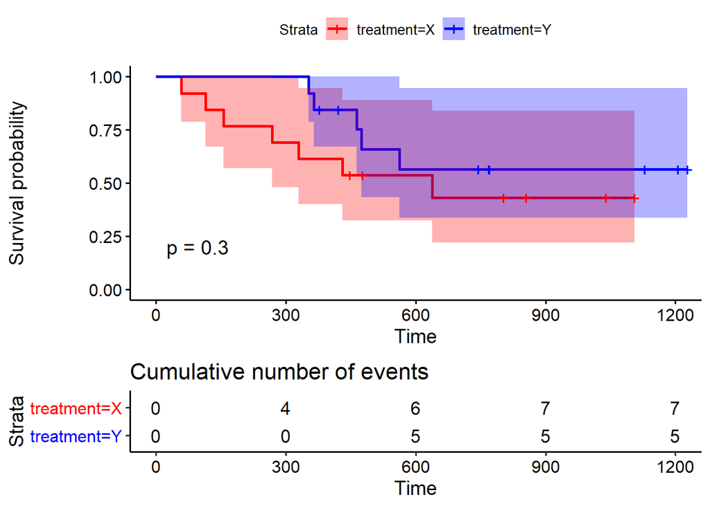

```r
ggsurvplot(km1, data=ovarian, palette=c('red','blue'), risk.table=F,cumevents=T,conf.int=T,tables.height=0.3,pval=T)
```

The crosses along the curves represent occurance of censoring at a given time. Despite for treatment group Y tending to perform better, the confidence intervals and the log-rank test (p=0.3) show that *treatment* has no influence on survival. This can partly be explained by the small sample size of 13 patients for each stratum.

## Cox proportional hazards model

In order to assess the potential influence of multiple variables, the Cox proportional hazards model can be used. It allows to examine how covariates influence the rate of event (e.g. death, infection) occuring at a particular time. The hazard ratios (HRs) derived from the model for a particular variable are indicative of an increased (HR>1) or decreased (HR<1) event probability, which is negatively associated with survival time. The Cox proportional HR model handles categorical as well as numerical covariates. In the first instance, a few nested competing candidate models will be fit and the most parsimonious one selected using likelihood ratio test (LRT).

```r
coxm1<-coxph(surv.obj ~ treatment * age_cat + resid.ds + ecog.ps, ovarian) # fit Cox PH candidate models
coxm2<-coxph(surv.obj ~ treatment + age_cat + resid.ds + ecog.ps, ovarian)
coxm3<-coxph(surv.obj ~ treatment + age_cat + resid.ds, ovarian)
```

The LRT is performed using the function *anova.coxph* (implemented as *anova*) from the package *survival*.

```r
anova(coxm2, coxm1)
```

```
## Analysis of Deviance Table
##  Cox model: response is  surv.obj
##  Model 1: ~ treatment + age_cat + resid.ds + ecog.ps
##  Model 2: ~ treatment * age_cat + resid.ds + ecog.ps
##    loglik Chisq Df P(>|Chi|)
## 1 -30.348
## 2 -30.154 0.389  1    0.5328
```

The *null hypothesis* in a LRT is that the smaller or simpler model performs significantly better (in terms of log-likelihood maximisation) than the more complex model (i.e. with more parameters). According to the LRT, the *null hypothesis* cannot be rejected (p=0.53). Therefore, the more compex model (*coxm1*) performs worse than the simpler model *coxm2*. Accordingly, there is no indication that *treatment* is influenced by patient’s *age_cat*: the interaction term between the two variables should not be included.

Does patient performance status (ECOG) contribute to model parsimony?

```r
anova(coxm3, coxm2)
```

```
## Analysis of Deviance Table
##  Cox model: response is  surv.obj
##  Model 1: ~ treatment + age_cat + resid.ds
##  Model 2: ~ treatment + age_cat + resid.ds + ecog.ps
##    loglik  Chisq Df P(>|Chi|)
## 1 -30.441
## 2 -30.348 0.1854  1    0.6668
```

Similarly, including the ECOG variable *ecog.ps* does not improve the model (p=0.67) and should be removed.

How does inclusion of the presence of residual disease (i.e. tumors) variable *resid.ps* contribute to model performance?

```r
coxm4<-coxph(surv.obj ~ treatment + age_cat, ovarian)
anova(coxm4,coxm3)
```

```
## Analysis of Deviance Table
##  Cox model: response is  surv.obj
##  Model 1: ~ treatment + age_cat
##  Model 2: ~ treatment + age_cat + resid.ds
##    loglik Chisq Df P(>|Chi|)
## 1 -32.117
## 2 -30.441 3.352  1   0.06712 .
## ---
## Signif. codes:  0 '***' 0.001 '**' 0.01 '*' 0.05 '.' 0.1 ' ' 1
```

Given a p-value of 0.067 variable *resid.ds* does not significantly contribute to the model. However, due to small sample size (N=26 patients) this borderline significance (paired with rationality) should provide (some might disagree) justification to retain *resid.vs* in the model.

```r
coxm5<-coxph(surv.obj ~ treatment + resid.ds, ovarian)
anova(coxm5,coxm3)
```

```
## Analysis of Deviance Table
##  Cox model: response is  surv.obj
##  Model 1: ~ treatment + resid.ds
##  Model 2: ~ treatment + age_cat + resid.ds
##    loglik Chisq Df P(>|Chi|)
## 1 -32.269
## 2 -30.441 3.655  1    0.0559 .
## ---
## Signif. codes:  0 '***' 0.001 '**' 0.01 '*' 0.05 '.' 0.1 ' ' 1
```

Similarly, *age_cat* is very close to the significance level of 0.05. If an influence from this variable on survival is rational, this variable should be retained in the model.

Does variable *treatment* contribute to model performance?

```r
coxm6<-coxph(surv.obj ~ age_cat + resid.ds, data=ovarian)
anova(coxm6,coxm3)
```

```
## Analysis of Deviance Table
##  Cox model: response is  surv.obj
##  Model 1: ~ age_cat + resid.ds
##  Model 2: ~ treatment + age_cat + resid.ds
##    loglik  Chisq Df P(>|Chi|)
## 1 -31.967
## 2 -30.441 3.0517  1   0.08065 .
## ---
## Signif. codes:  0 '***' 0.001 '**' 0.01 '*' 0.05 '.' 0.1 ' ' 1
```

Again, variable *treatment* is just on the brink to significance (p=0.081), and should therefore not be discarded by implication.  
Considering that it is very reasonable to assume that *treatment* likely had an effect on patient survival, the variable should (imho) remain in the model.

```r
AIC(coxm1, coxm2, coxm3, coxm4, coxm5, coxm6)
```

```
##       df      AIC
## coxm1  5 70.30778
## coxm2  4 68.69682
## coxm3  3 66.88224
## coxm4  2 68.23422
## coxm5  2 68.53723
## coxm6  2 67.93391
```

Conclusive with the LRT-based model selection process above, model *coxm3* has lowest AIC and will be used for inference. The assumption of proportional hazard ratios (HR’s) in a Cox proportional HR model can be tested using the *cox.zph* function. The undelying null hypothesis is that the HR’s are proportional.

```r
cox.zph(coxm3)
```

```
##                rho chisq      p
## treatmentY   0.473 2.715 0.0994
## age_catold  -0.181 0.371 0.5426
## resid.dspos -0.487 2.601 0.1068
## GLOBAL          NA 4.618 0.2020
```

Conveniently, model results can be visualised in a forest-plot using the *ggforest* function.

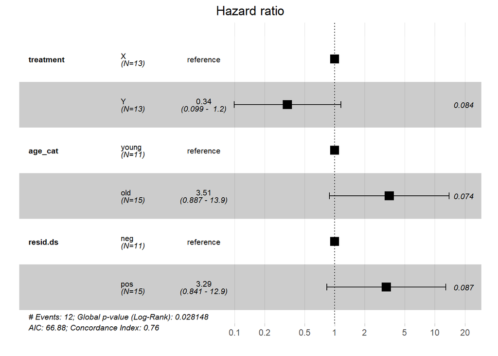

```r
ggforest(coxm3, ovarian)
```

According to the Cox PH model *coxm3*, at any particular time on average about a third (mean hazard ratio of 0.34 (95%CI 0.1-1.2, p=0.084)) as many patients receiving *treatment* Y were experiencing death compared to patients receiving *treatment* X. On average more than 3 times as many older patients died (mean hazard ratio of 3.51 (95%CI 0.89-13.9, p=0.074)) compared to younger patients. Similarly, more than three times as many patients with positive residual disease (mean hazard ratio of 3.29 (95%CI 0.84-12.9, p=0.087)) died compared to the group with negative residual disease.

The estimated survival rate can be displayed for different strata (here different *age_cat*):

```r
age_df<-with(na.omit(ovarian),data.frame(age_cat=levels(ovarian$age_cat), treatment="X", resid.ds="pos")) # create new data frame with new age groups
fit1<-survfit(coxm3, data=ovarian,newdata=age_df) #create survival curves from coxm3 model.
fit1
```

```
## Call: survfit(formula = coxm3, newdata = age_df, data = ovarian)
##
##    n events median 0.95LCL 0.95UCL
## 1 26     12    563     365      NA
## 2 26     12    329     156      NA
```

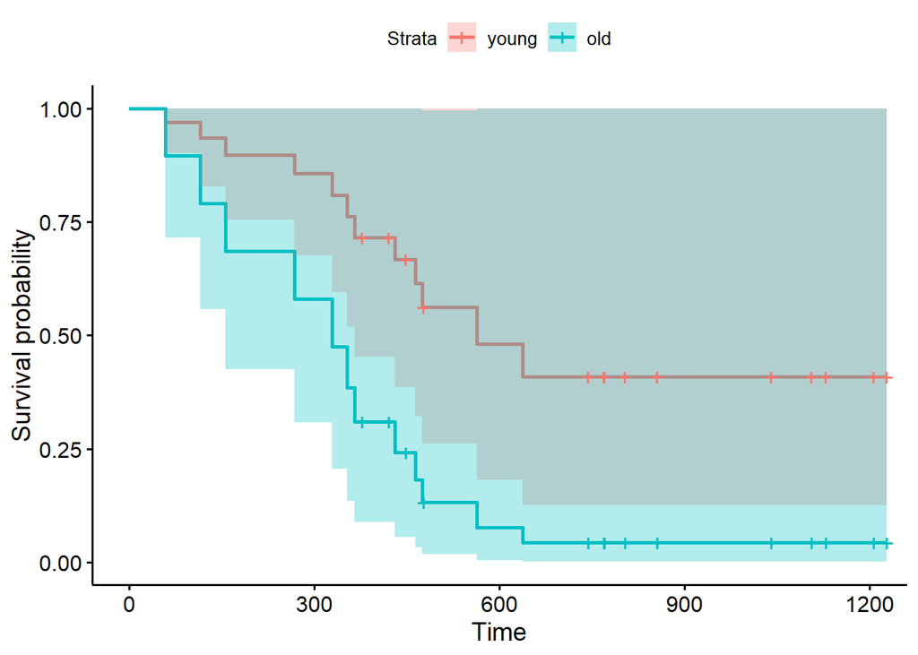

```r
#Attention! Upper 95% Confidence limit is not provided here, which results in tremendous ovelap of 95%CIs from both strata.
ggsurvplot(fit1, conf.int=T, legend.labs=c("young", "old"))
```

## Calculate survival probability

First, determine the expected number of events given different *age_cat* (“young” vs “old”) and some follow-up time:

```r
survexp.young<-predict(coxph(Surv(time=futime, event=fustat)~age_cat + treatment + resid.ds, data=ovarian), newdata=list(futime=600, fustat=1, age_cat="young", treatment="X", resid.ds="pos"), type="expected")
survexp.old<-predict(coxph(Surv(time=futime, event=fustat)~age_cat + treatment + resid.ds, data=ovarian), newdata=list(futime=600, fustat=1, age_cat="old", treatment="X", resid.ds="pos"), type="expected")
```

The actual probability to survive 600 days for a young and an old patient is given as:

```r
c(exp(-survexp.young),exp(-survexp.old))
```

```
## [1] 0.48024523 0.07634759
```

As has already been displayed in the plot above, the probability to survive the first 600 days tends to be much lower for older patients (only 7.6%) compared to younger patients (48.02%).

Thank you for reading this!